# Lab4_Will

### 3.3 Fifth layer Perceptron:

```python
class FiveLayerPerceptronBase(object):
    def __init__(self, n1_hidden=30,n2_hidden=30,n3_hidden=10,n4_hidden=8,
                 C=0.0, epochs=500, eta=0.001, random_state=None):
        np.random.seed(random_state)
        self.n1_hidden = n1_hidden
        self.n2_hidden = n2_hidden   # Number of hidden in third layer.
        self.n3_hidden = n3_hidden   # Number of hidden in fourth layer.
        self.n4_hidden = n4_hidden   # Number of hidden in fourth layer.
        self.l2_C = C
        self.epochs = epochs
        self.eta = eta

    @staticmethod
    def _encode_labels(y):
        """Encode labels into one-hot representation"""
        onehot = pd.get_dummies(y).values.T

        return onehot

    def _initialize_weights(self):
        """Initialize weights with small random numbers."""
        W1_num_elems = (self.n_features_ + 1)*self.n1_hidden
        W1 = np.random.uniform(-1.0, 1.0,size=W1_num_elems)
        W1 = W1.reshape(self.n1_hidden, self.n_features_ + 1) # reshape to be W

        W2_num_elems = (self.n1_hidden + 1)*self.n2_hidden_
        W2 = np.random.uniform(-1.0, 1.0, size=W2_num_elems)
        W2 = W2.reshape(self.n2_hidden_, self.n1_hidden + 1)

        W3_num_elems = (self.n2_hidden + 1)*self.n3_hidden_
        W3 = np.random.uniform(-1.0, 1.0, size=W3_num_elems)
        W3 = W3.reshape(self.n3_hidden_, self.n2_hidden + 1)

        W4_num_elems = (self.n3_hidden + 1)*self.n4_hidden_
        W4 = np.random.uniform(-1.0, 1.0, size=W4_num_elems)
        W4 = W3.reshape(self.n4_hidden_, self.n3_hidden + 1)

        W5_num_elems = (self.n4_hidden + 1)*self.n_output_
        W5 = np.random.uniform(-1.0, 1.0, size=W5_num_elems)
        W5 = W4.reshape(self.n_output_, self.n4_hidden + 1)
        return W1, W2 , W3 , W4 , W5

    @staticmethod
    def _sigmoid(z):
        """Use scipy.special.expit to avoid overflow"""
        # 1.0 / (1.0 + np.exp(-z))
        return expit(z)

    @staticmethod
    def _add_bias_unit(X, how='column'):
        """Add bias unit (column or row of 1s) to array at index 0"""
        if how == 'column':
            ones = np.ones((X.shape[0], 1))
            X_new = np.hstack((ones, X))
        elif how == 'row':
            ones = np.ones((1, X.shape[1]))
            X_new = np.vstack((ones, X))
        return X_new

    @staticmethod
    def _L2_reg(lambda_, W1, W2, W3, W4,W5):
        """Compute L2-regularization cost"""
        # only compute for non-bias terms
        return (lambda_/2.0) * np.sqrt(np.mean(W1[:, 1:] ** 2) + np.mean(W2[:, 1:] ** 2) + np.mean(W3[:, 1:] ** 2)
                                       + np.mean(W4[:, 1:] ** 2) + np.mean(W5[:, 1:] ** 2))

    def _cost(self,A6,Y_enc,W1, W2, W3, W4, W5):
        '''Get the objective function value'''
        cost = np.mean((Y_enc-A6)**2)
        L2_term = self._L2_reg(self.l2_C, W1, W2, W3, W4, W5)
        return cost + L2_term

    def _feedforward(self, X, W1, W2, W3, W4, W5):
        """Compute feedforward step
        """
        A1 = self._add_bias_unit(X, how='column')
        A1 = A1.T
        Z1 = W1 @ A1

        A2 = self._sigmoid(Z1)
        A2 = self._add_bias_unit(A2, how='row')
        Z2 = W2 @ A2

        A3 = self._sigmoid(Z2)
        A3 = self._add_bias_unit(A3, how='row')
        Z3 = W3 @ A3

        A4 = self._sigmoid(Z3)
        A4 = self._add_bias_unit(A4, how='row')
        Z4 = W4 @ A4

        A5 = self._sigmoid(Z4)
        A5 = self._add_bias_unit(A5, how='row')
        Z5 = W5 @ A5

        A6 = self._sigmoid(Z5)
        return A1, Z1, A2, Z2, A3, Z3, A4, Z4, A5, Z5, A6

    def _get_gradient(self, A1, A2, A3, A4, A5,A6, Z1, Z2, Z3, Z4, Z5,  Y_enc, W1, W2, W3, W4, W5):
        """ Compute gradient step using backpropagation.
        """
        # vectorized backpropagation
        V5 = -2*(Y_enc-A6)*A6*(1-A6)  # last layer sensitivity
        V4 = A5*(1-A5)*(W5.T @ V5) # back prop the sensitivity
        V3 = A4*(1-A4)*(W4.T @ V4[1:,:]) # back prop the sensitivity
        V2 = A3*(1-A3)*(W3.T @ V3[1:,:]) # back prop the sensitivity
        V1 = A2*(1-A2)*(W2.T @ V2[1:,:]) # back prop the sensitivity


        grad5 = V5 @ A5.T # no bias on final layer
        grad4 = V4[1:,:] @ A4.T # dont back prop sensitivity of bias
        grad3 = V3[1:,:] @ A3.T # dont back prop sensitivity of bias
        grad2 = V2[1:,:] @ A2.T # dont back prop sensitivity of bias
        grad1 = V1[1:,:] @ A1.T # dont back prop sensitivity of bias


        # regularize weights that are not bias terms
        grad1[:, 1:] += W1[:, 1:] * self.l2_C
        grad2[:, 1:] += W2[:, 1:] * self.l2_C
        grad3[:, 1:] += W3[:, 1:] * self.l2_C
        grad4[:, 1:] += W4[:, 1:] * self.l2_C
        grad5[:, 1:] += W5[:, 1:] * self.l2_C
        return grad1, grad2, grad3, grad4 , grad5


    def predict(self, X):
        """Predict class labels"""
        _, _, _, _,_, _,_, _, _, _, A6 = self._feedforward(X, self.W1, self.W2, self.W3, self.W4, self.W5)
        y_pred = np.argmax(A6, axis=0)
        return y_pred



# mini-batching
class FiLPMiniBatch(FiveLayerPerceptronBase):
    def __init__(self, alpha=0.0, decrease_const=0.0,
                 decrease_iter = 10,shuffle=True,
                 minibatches=1, **kwds):
        # need to add to the original initializer
        self.alpha = alpha
        self.decrease_const = decrease_const
        self.decrease_iter = decrease_iter
        self.shuffle = shuffle
        self.minibatches = minibatches
        # but keep other keywords
        super().__init__(**kwds)


    def fit(self, X, y, print_progress=False, XY_test=None):
        """ Learn weights from training data. With mini-batch"""
        X_data, y_data = X.copy(), y.copy()
        Y_enc = self._encode_labels(y)

         # Convert to numpy arrays if not already
        X_data = np.array(X_data)
        Y_enc = np.array(Y_enc)
        y_data = np.array(y_data)
        # init weights and setup matrices
        self.n_features_ = X_data.shape[1]
        self.n_output_ = Y_enc.shape[0]
        self.W1, self.W2 , self.W3 ,self.W4 ,self.W5 = self._initialize_weights()
```

```python
        rho_W1_prev = np.zeros(self.W1.shape)
        rho_W2_prev = np.zeros(self.W2.shape)
        rho_W3_prev = np.zeros(self.W3.shape)
        rho_W4_prev = np.zeros(self.W4.shape)
        rho_W5_prev = np.zeros(self.W5.shape)


        self.cost_ = []
        self.score_ = []
        # get starting acc
        self.score_.append(accuracy_score(y_data,self.predict(X_data)))
        # keep track of validation, if given
        if XY_test is not None:
            X_test = XY_test[0].copy()
            y_test = XY_test[1].copy()
            self.val_score_ = []
            self.val_score_.append(accuracy_score(y_test,self.predict(X_test)))



        # You will update These arrays, initialized here
        self.grad_w1_ = np.zeros(self.epochs)
        self.grad_w2_ = np.zeros(self.epochs)
        self.grad_w3_ = np.zeros(self.epochs)
        self.grad_w4_ = np.zeros(self.epochs)
        self.grad_w5_ = np.zeros(self.epochs)


        for i in range(self.epochs):

            # adaptive learning rate
            # \frac{\eta}{1+\epsilon\cdot k}
            eta = self.eta * self.decrease_const**(np.floor(i/self.decrease_iter))
            if print_progress>0 and (i+1)%print_progress==0:
                sys.stderr.write('\rEpoch: %d/%d' % (i+1, self.epochs))
                sys.stderr.flush()

            if self.shuffle:
                idx_shuffle = np.random.permutation(y_data.shape[0])
                X_data, Y_enc, y_data = X_data[idx_shuffle], Y_enc[:, idx_shuffle], y_data[idx_shuffle]

            mini = np.array_split(range(y_data.shape[0]), self.minibatches)
            mini_cost = []

            mini_grad1 = []
            mini_grad2 = []
            mini_grad3 = []
            mini_grad4 = []
            mini_grad5 = []

            for idx in mini:

                # feedforward
                A1, Z1, A2, Z2,A3, Z3,A4, Z4, A5, Z5, A6 = self._feedforward(X_data[idx],
                                                       self.W1,
                                                       self.W2,
                                                       self.W3,
                                                       self.W4,
                                                       self.W5)

                cost = self._cost(A6,Y_enc[:, idx],self.W1,self.W2,self.W3,self.W4,self.W5)
                mini_cost.append(cost) # this appends cost of mini-batch only

                # compute gradient via backpropagation
                grad1, grad2 ,grad3,grad4 ,grad5 = self._get_gradient(A1=A1, A2=A2, A3=A3, A4=A4, A5=A5,A6 =A6,
                                                  Z1=Z1, Z2=Z2, Z3=Z3, Z4=Z4, Z5=Z5,
                                                  Y_enc=Y_enc[:, idx],
                                                  W1=self.W1, W2=self.W2, W3=self.W3, W4=self.W4, W5=self.W5)


                mini_grad1.append(grad1)
                mini_grad2.append(grad2)
                mini_grad3.append(grad3)
                mini_grad4.append(grad4)
                mini_grad5.append(grad5)

                # momentum calculations
                rho_W1, rho_W2 , rho_W3 , rho_W4 ,rho_W5 = eta * grad1, eta * grad2,eta * grad3 ,eta * grad4 ,eta * grad5
                self.W1 -= (rho_W1 + (self.alpha * rho_W1_prev))
                self.W2 -= (rho_W2 + (self.alpha * rho_W2_prev))
                self.W3 -= (rho_W3 + (self.alpha * rho_W3_prev))
                self.W4 -= (rho_W4 + (self.alpha * rho_W4_prev))
                self.W5 -= (rho_W5 + (self.alpha * rho_W5_prev))

                rho_W1_prev, rho_W2_prev, rho_W3_prev, rho_W4_prev ,rho_W5_prev = rho_W1, rho_W2 , rho_W3, rho_W4 , rho_W5

                        # Track the magnitude of the gradient
            self.grad_w1_[i] = np.mean(np.abs(np.mean(mini_grad1[:])))
            self.grad_w2_[i] = np.mean(np.abs(np.mean(mini_grad2[:])))
            self.grad_w3_[i] = np.mean(np.abs(np.mean(mini_grad3[:])))
            self.grad_w4_[i] = np.mean(np.abs(np.mean(mini_grad4[:])))
            self.grad_w5_[i] = np.mean(np.abs(np.mean(mini_grad5[:])))

            self.cost_.append(mini_cost)
            self.score_.append(accuracy_score(y_data,self.predict(X_data)))
            if XY_test is not None:
                self.val_score_.append(accuracy_score(y_test,self.predict(X_test)))

        return self


# Cross Entropy Loss

class FiLPMiniBatchCrossEntropy(FiLPMiniBatch):
    def _cost(self,A6,Y_enc,W1,W2,W3,W4,W5):
        '''Get the objective function value'''
        cost = -np.mean(np.nan_to_num((Y_enc*np.log(A6)+(1-Y_enc)*np.log(1-A6))))
        L2_term = self._L2_reg(self.l2_C, W1, W2, W3, W4, W5)
        return cost + L2_term

    def _get_gradient(self, A1, A2, A3, A4, A5, A6, Z1, Z2, Z3, Z4, Z5, Y_enc, W1, W2 ,W3, W4, W5):
        """ Compute gradient step using backpropagation.
        """
        # vectorized backpropagation
        V5 = (A6-Y_enc) # <- this is only line that changed
        V4 = A5*(1-A5)*(W5.T @ V5)
        V3 = A4*(1-A4)*(W4.T @ V4[1:,:])
        V2 = A3*(1-A3)*(W3.T @ V3[1:,:])
        V1 = A2*(1-A2)*(W2.T @ V2[1:,:])

        grad5 = V5 @ A5.T
        grad4 = V4[1:,:] @ A4.T
        grad3 = V3[1:,:] @ A3.T
        grad2 = V2[1:,:] @ A2.T
        grad1 = V1[1:,:] @ A1.T

        # regularize weights that are not bias terms
        grad1[:, 1:] += W1[:, 1:] * self.l2_C
        grad2[:, 1:] += W2[:, 1:] * self.l2_C
        grad3[:, 1:] += W3[:, 1:] * self.l2_C
        grad4[:, 1:] += W4[:, 1:] * self.l2_C
        grad5[:, 1:] += W5[:, 1:] * self.l2_C

        return grad1, grad2 , grad3 , grad4 ,grad5



# proper Glorot initialization

class FiLPBetterInitial(FiLPMiniBatchCrossEntropy):
    def _initialize_weights(self):
        """Initialize weights Glorot and He normalization."""
        init_bound = 4*np.sqrt(6. / (self.n1_hidden + self.n_features_ + 1))
        W1 = np.random.uniform(-init_bound, init_bound,(self.n1_hidden, self.n_features_ + 1))
        W1[:,:1] = 0

        # reduce the final layer magnitude in order to balance the size of the gradients
        # between
        init_bound = 4*np.sqrt(6 / (self.n2_hidden + self.n1_hidden + 1))
        W2 = np.random.uniform(-init_bound, init_bound,(self.n2_hidden, self.n1_hidden + 1))
        W2[:,:1] = 0
```

```python
        init_bound = 4*np.sqrt(6 / (self.n3_hidden + self.n2_hidden + 1))
        W3 = np.random.uniform(-init_bound, init_bound,(self.n3_hidden, self.n2_hidden + 1))
        W3[:,:1] = 0

        init_bound = 4*np.sqrt(6 / (self.n4_hidden + self.n3_hidden + 1))
        W4 = np.random.uniform(-init_bound, init_bound,(self.n4_hidden, self.n3_hidden + 1))
        W4[:,:1] = 0

        init_bound = 4*np.sqrt(6 / (self.n_output_ + self.n4_hidden + 1))
        W5 = np.random.uniform(-init_bound, init_bound,(self.n_output_, self.n4_hidden + 1))
        W5[:,:1] = 0

        return W1, W2, W3, W4 ,W5
```

```
Epoch: 140/140No artists with labels found to put in legend.  Note that artists whose label start with an underscore are ignored when legend() is called with no argument.
```

```
=================
 :
Resubstitution acc: 0.7440093512565751
Validation acc: 0.7383113311331133
```

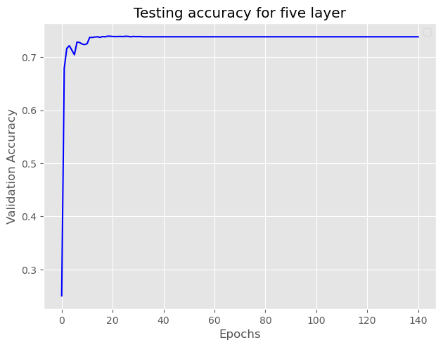

```python
vals5 = {'n1_hidden':70, 'n2_hidden':50, 'n3_hidden':30,  'n4_hidden':10,
         'C':1e-2, 'epochs':140, 'eta':0.01, 'random_state':1,
         'alpha':0.1, 'decrease_const':0.1, 'minibatches':len(X_train)/256,
         'shuffle':True}

nn_cross_five = FiLPBetterInitial(**vals5)
nn_cross_five.fit(X_trained, y_train_class, print_progress=1, XY_test=(X_tested, y_test_class));

print_result(nn_cross_five,X_trained,y_train_class,X_tested,y_test_class,color="blue")
plt.title('Testing accuracy for five layer')
plt.show()
```

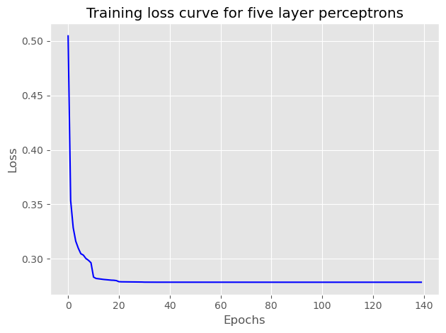

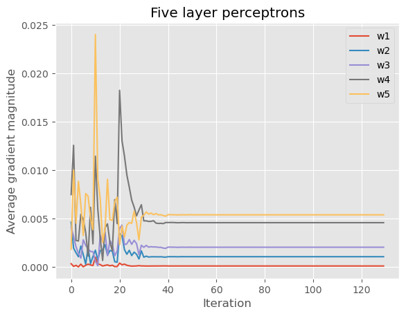

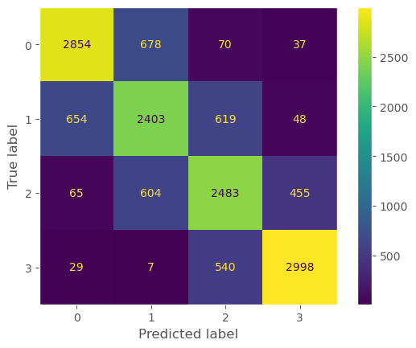

```python
cost_avgs_6 = [np.mean(x) for x in nn_cross_five.cost_]

plt.plot(range(len(cost_avgs_6)), cost_avgs_6, color='blue')
plt.ylabel('Loss')
plt.xlabel('Epochs')
plt.title('Training loss curve for five layer perceptrons')
plt.tight_layout()
plt.show()

ax = plt.subplot(1,1,1)
plt.plot(np.abs(nn_cross_five.grad_w1_[10:]), label='w1')
plt.plot(np.abs(nn_cross_five.grad_w2_[10:]), label='w2')
plt.plot(np.abs(nn_cross_five.grad_w3_[10:]), label='w3')
plt.plot(np.abs(nn_cross_five.grad_w4_[10:]), label='w4')
plt.plot(np.abs(nn_cross_five.grad_w5_[10:]), label='w5')
plt.legend()
plt.title('Five layer perceptrons')
plt.ylabel('Average gradient magnitude')
plt.xlabel('Iteration')
plt.show()

yhat_five = nn_cross_five.predict(X_tested)
Acc_five = accuracy_score(y_test_class,yhat_five)
cm = confusion_matrix(y_test_class,yhat_five)
disp = ConfusionMatrixDisplay(confusion_matrix=cm)
disp.plot()
plt.grid(False)

plt.show()
```

### 3.4 Adaptive Learning

Implement an adaptive learning technique that was discussed in lecture and use it on the five layer network (choose either RMSProp or AdaDelta). Discuss which adaptive method you chose. Compare the performance of your five layer model with and without the adaptive learning strategy.

```python
class FiLPRMSProp(FiLPBetterInitial):

    def __init__(self, eps=0.0, gamma=0.0, **kwds):
        # need to add to the original initializer
        self.eps = eps
        self.gamma = gamma
        # but keep other keywords
        super().__init__(**kwds) ##


    def fit(self, X, y, print_progress=False, XY_test=None):

        """ Learn weights from training data. With mini-batch"""
        X_data, y_data = X.copy(), y.copy()
        Y_enc = self._encode_labels(y)

        # init weights and setup matrices
        self.n_features_ = X_data.shape[1]
        self.n_output_ = Y_enc.shape[0]
        self.W1, self.W2, self.W3, self.W4, self.W5 = self._initialize_weights()

                 # keep track of gradients of each epoch
        V1_prev = np.zeros(self.W1.shape)
        V2_prev = np.zeros(self.W2.shape)
        V3_prev = np.zeros(self.W3.shape)
        V4_prev = np.zeros(self.W4.shape)
        V5_prev = np.zeros(self.W5.shape)

                # start momentum at zero for previous updates
        rho_W1_prev = np.zeros(self.W1.shape) # for momentum
        rho_W2_prev = np.zeros(self.W2.shape) # for momentum
        rho_W3_prev = np.zeros(self.W3.shape) # for momentum
        rho_W4_prev = np.zeros(self.W4.shape) # for momentum
        rho_W5_prev = np.zeros(self.W5.shape) # for momentum

        self.cost_ = []
        self.score_ = []
        # get starting acc
        self.score_.append(accuracy_score(y_data,self.predict(X_data)))
        # keep track of validation, if given
        if XY_test is not None:
            X_test = XY_test[0].copy()
            y_test = XY_test[1].copy()
            self.val_score_ = []
            self.val_score_.append(accuracy_score(y_test,self.predict(X_test)))



        self.grad_w1_ = np.zeros(self.epochs)
        self.grad_w2_ = np.zeros(self.epochs)
        self.grad_w3_ = np.zeros(self.epochs)
        self.grad_w4_ = np.zeros(self.epochs)
        self.grad_w5_ = np.zeros(self.epochs)

        for i in range(self.epochs):

            # adaptive learning rate
            # decrease at certain epochs
            eta = self.eta * self.decrease_const**(np.floor(i/self.decrease_iter))

            if print_progress>0 and (i+1)%print_progress==0:
                sys.stderr.write('\rEpoch: %d/%d' % (i+1, self.epochs))
                sys.stderr.flush()

            if self.shuffle:
                idx_shuffle = np.random.permutation(y_data.shape[0])
                X_data, Y_enc, y_data = X_data[idx_shuffle], Y_enc[:, idx_shuffle], y_data[idx_shuffle]

            mini = np.array_split(range(y_data.shape[0]), self.minibatches)
            mini_cost = []

            mini_grad1 = []
            mini_grad2 = []
            mini_grad3 = []
            mini_grad4 = []
            mini_grad5 = []

            for idx in mini:

                # feedforward
                A1, Z1, A2, Z2, A3, Z3, A4, Z4, A5,Z5, A6 = self._feedforward(X_data[idx],
                                                       self.W1,
                                                       self.W2, self.W3, self.W4,self.W5)

                cost = self._cost(A6, Y_enc[:, idx],self.W1,self.W2, self.W3,self.W4, self.W5 )
                mini_cost.append(cost) # this appends cost of mini-batch only

                # compute gradient via backpropagation
                gradW1, gradW2, gradW3, gradW4, gradW5  = self._get_gradient(A1=A1, A2=A2, A3=A3, A4=A4, A5=A5,
                                                  A6=A6,
                                                  Z1=Z1, Z2=Z2, Z3=Z3, Z4=Z4,Z5=Z5,
                                                  Y_enc=Y_enc[:, idx],
                                                  W1=self.W1, W2=self.W2, W3=self.W3,
                                                  W4=self.W4, W5=self.W5)


                V1 = self.gamma*V1_prev + (1-self.gamma)*gradW1*gradW1
                V2 = self.gamma*V2_prev + (1-self.gamma)*gradW2*gradW2
                V3 = self.gamma*V3_prev + (1-self.gamma)*gradW3*gradW3
                V4 = self.gamma*V4_prev + (1-self.gamma)*gradW4*gradW4
                V5 = self.gamma*V5_prev + (1-self.gamma)*gradW5*gradW5


                # momentum and adagrad
                rho_W1, rho_W2,rho_W3,rho_W4,rho_W5 = eta * gradW1/np.sqrt(V1 +self.eps), eta * gradW2/np.sqrt(V2 +self.eps),eta * gradW3/np.sqrt(V3+self.eps),eta * gradW4/np.sqrt(V4+self.eps),eta * gradW5/np.sqrt(V5+self.eps)
                self.W1 -= (rho_W1 + (self.alpha * rho_W1_prev)) # update with momentum
                self.W2 -= (rho_W2 + (self.alpha * rho_W2_prev)) # update with momentum
                self.W3 -= (rho_W3 + (self.alpha * rho_W3_prev)) # update with momentum
                self.W4 -= (rho_W4 + (self.alpha * rho_W4_prev)) # update with momentum
                self.W5 -= (rho_W5 + (self.alpha * rho_W5_prev)) # update with momentum


                # update previous parameters for the
                rho_W1_prev, rho_W2_prev,rho_W3_prev,rho_W4_prev,rho_W5_prev = rho_W1, rho_W2, rho_W3, rho_W4, rho_W5
                V1_prev, V2_prev, V3_prev, V4_prev, V5_prev = V1, V2, V3,V4,V5


                 # keep track of gradients of each minibach in each epoch
                mini_grad1.append(gradW1)
                mini_grad2.append(gradW2)
                mini_grad3.append(gradW3)
                mini_grad4.append(gradW4)
                mini_grad5.append(gradW5)




            self.grad_w1_[i] = np.mean(np.abs((np.mean(mini_grad1[:]))))
            self.grad_w2_[i] = np.mean(np.abs((np.mean(mini_grad2[:]))))
            self.grad_w3_[i] = np.mean(np.abs((np.mean(mini_grad3[:]))))
            self.grad_w4_[i] = np.mean(np.abs((np.mean(mini_grad4[:]))))
            self.grad_w5_[i] = np.mean(np.abs((np.mean(mini_grad5[:]))))

            self.cost_.append(mini_cost)
            self.score_.append(accuracy_score(y_data,self.predict(X_data)))
            if XY_test is not None:
                self.val_score_.append(accuracy_score(y_test,self.predict(X_test)))


        return self
```

```
Epoch: 140/140
```

```
=================
 :
Resubstitution acc: 0.7552514869185547
Validation acc: 0.7396177117711771
```

```
No artists with labels found to put in legend.  Note that artists whose label start with an underscore are ignored when legend() is called with no argument.
```

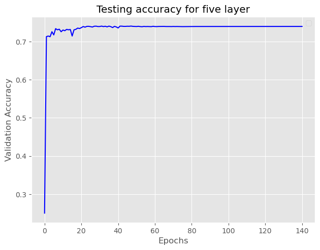

```python
vals_Ap = {'n1_hidden':70, 'n2_hidden':50, 'n3_hidden':30,  'n4_hidden':10,
         'C':1e-2, 'epochs':140, 'eta':0.01, 'random_state':1, 'decrease_iter':20, 'eps':1e-3, 'gamma':0.9,
         'alpha':0.1, 'decrease_const':0.1, 'minibatches':len(X_train)/256,
         'shuffle':True}

nn_Ap = FiLPRMSProp(**vals_Ap)
nn_Ap.fit(X_trained, y_trained, print_progress=1, XY_test=(X_tested, y_tested));

print_result(nn_Ap,X_trained,y_train_class,X_tested,y_test_class,color="blue")
plt.title('Testing accuracy for five layer')
plt.show()
```

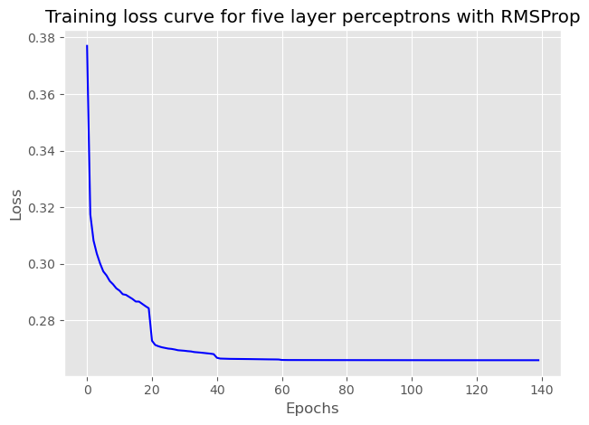

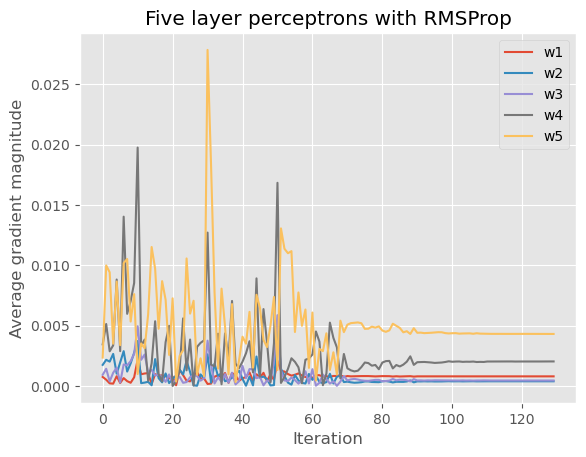

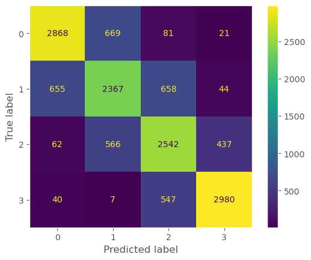

```python
cost_avgs = [np.mean(x) for x in nn_Ap.cost_]

plt.plot(range(len(cost_avgs)), cost_avgs, color='blue')
plt.ylabel('Loss')
plt.xlabel('Epochs')
plt.title('Training loss curve for five layer perceptrons with RMSProp')

plt.tight_layout()
plt.show()

ax = plt.subplot(1,1,1)
plt.plot(np.abs(nn_Ap.grad_w1_[10:]), label='w1')
plt.plot(np.abs(nn_Ap.grad_w2_[10:]), label='w2')
plt.plot(np.abs(nn_Ap.grad_w3_[10:]), label='w3')
plt.plot(np.abs(nn_Ap.grad_w4_[10:]), label='w4')
plt.plot(np.abs(nn_Ap.grad_w5_[10:]), label='w5')
plt.legend()
plt.ylabel('Average gradient magnitude')
plt.title('Five layer perceptrons with RMSProp')
plt.xlabel('Iteration')
plt.show()

yhat_five_RMSProp = nn_Ap.predict(X_tested)
Acc_five_RMSProp=accuracy_score(y_tested,yhat_five_RMSProp)
cm = confusion_matrix(y_tested,yhat_five_RMSProp)
disp = ConfusionMatrixDisplay(confusion_matrix=cm)
disp.plot()
plt.grid(False)

plt.show()
```

Training data for the five-layer perceptron using the RMSProp Adaptive Learning Technique included one-hot-encoded characteristics and normalized numerical data.

According to the Cost vs. epoch figure, training converges after around 40 epochs.

The prediction accuracy of the model is 74%, indicating that the inclusion of a fifth layer did not improve it.

#### 3.4A Comparison:

```python
print('The comparison between FLP "without RMSProp" and "with RMSProp" with 95% confidence interval is as follows:')
table = mcnemar_table(y_target=y_test_class, y_model1=yhat_five, y_model2=yhat_five_RMSProp)
chi2_, p = mcnemar(ary=table1, corrected=True)
print(table)
print(f"chi² statistic: {chi2_}, p-value: {p}")
if p > 0.05:
    print("Same proportions of errors (fail to reject Null Hypothesis--There isn't enough evidence to suggest that the Five Layer Perceptron models with and without RMSProp are different from each other)")
else:
        print('Different proportions of errors (reject H0)')




print(f'                   With RMSProp              Without RMSProp')

print(f' Accuracy        {Acc_five_RMSProp}          {Acc_five}')
```

[output not shown]

## 4. Exceptional Work

### Adaptive Momentum (Adam) Application in the Five-Layer Perceptron.

Adam is a deep neural network training technique that uses adaptive learning rate optimization. It combines the benefits of AdaGrad and RMSProp, two more stochastic gradient descent additions. Adam uses momentum to enhance convergence and calculates adaptive learning rates for every parameter.

#### Step 1: Apply the AdaM Algorithm

```python
class FiLPAdam(FiLPBetterInitial):
    def __init__(self, eps=1e-7, beta1=0.9, beta2=0.999, **kwds):
        # Initialize AdaM parameters
        self.eps = eps
        self.beta1 = beta1
        self.beta2 = beta2
        # Initialize with other keywords
        super().__init__(**kwds)

    def fit(self, X, y, print_progress=False, XY_test=None):
        # Track gradients of each epoch
        self.grad_w1_ = np.zeros(self.epochs)
        self.grad_w2_ = np.zeros(self.epochs)
        self.grad_w3_ = np.zeros(self.epochs)
        self.grad_w4_ = np.zeros(self.epochs)
        self.grad_w5_ = np.zeros(self.epochs)

        """ Learn weights from training data. With mini-batch"""
        X_data, y_data = X.copy(), y.copy()
        Y_enc = self._encode_labels(y)

        # Initialize weights and setup matrices
        self.n_features_ = X_data.shape[1]
        self.n_output_ = Y_enc.shape[0]
        self.W1, self.W2, self.W3, self.W4, self.W5 = self._initialize_weights()

        self.cost_ = []
        self.score_ = []
        # Get initial accuracy
        self.score_.append(accuracy_score(y_data, self.predict(X_data)))
        # Track validation if provided
        if XY_test is not None:
            X_test, y_test = XY_test
            self.val_score_ = []
            self.val_score_.append(accuracy_score(y_test, self.predict(X_test)))

        M1_prev = np.zeros_like(self.W1)
        M2_prev = np.zeros_like(self.W2)
        M3_prev = np.zeros_like(self.W3)
        M4_prev = np.zeros_like(self.W4)
        M5_prev = np.zeros_like(self.W5)

        V1_prev = np.zeros_like(self.W1)
        V2_prev = np.zeros_like(self.W2)
        V3_prev = np.zeros_like(self.W3)
        V4_prev = np.zeros_like(self.W4)
        V5_prev = np.zeros_like(self.W5)

        for epoch in range(self.epochs):
            if print_progress > 0 and (epoch + 1) % print_progress == 0:
                sys.stderr.write(f'\rEpoch: {epoch + 1}/{self.epochs}')
                sys.stderr.flush()

            if self.shuffle:
                idx_shuffle = np.random.permutation(y_data.shape[0])
                X_data, Y_enc, y_data = X_data[idx_shuffle], Y_enc[:, idx_shuffle], y_data[idx_shuffle]

            mini_batches = np.array_split(range(y_data.shape[0]), self.minibatches)
            mini_cost = []

            mini_grad1 = []
            mini_grad2 = []
            mini_grad3 = []
            mini_grad4 = []
            mini_grad5 = []

            for idx in mini_batches:
                # Feedforward
                A1, Z1, A2, Z2, A3, Z3, A4, Z4, A5, Z5, A6 = self._feedforward(X_data[idx],
                                                                               self.W1,
                                                                               self.W2, self.W3, self.W4, self.W5)

                cost = self._cost(A6, Y_enc[:, idx], self.W1, self.W2, self.W3, self.W4, self.W5)
                mini_cost.append(cost)  # Append cost of mini-batch

                # Compute gradient via backpropagation
                G1, G2, G3, G4, G5 = self._get_gradient(A1, A2, A3, A4, A5, A6,
                                                        Z1, Z2, Z3, Z4, Z5,
                                                        Y_enc[:, idx],
                                                        self.W1, self.W2, self.W3, self.W4, self.W5)

                M1 = self.beta1 * M1_prev + (1 - self.beta1) * G1
                M2 = self.beta1 * M2_prev + (1 - self.beta1) * G2
                M3 = self.beta1 * M3_prev + (1 - self.beta1) * G3
                M4 = self.beta1 * M4_prev + (1 - self.beta1) * G4
                M5 = self.beta1 * M5_prev + (1 - self.beta1) * G5

                V1 = self.beta2 * V1_prev + (1 - self.beta2) * (G1 ** 2)
                V2 = self.beta2 * V2_prev + (1 - self.beta2) * (G2 ** 2)
                V3 = self.beta2 * V3_prev + (1 - self.beta2) * (G3 ** 2)
                V4 = self.beta2 * V4_prev + (1 - self.beta2) * (G4 ** 2)
                V5 = self.beta2 * V5_prev + (1 - self.beta2) * (G5 ** 2)

                M1_hat = M1 / (1 - self.beta1 ** (epoch + 1))
                M2_hat = M2 / (1 - self.beta1 ** (epoch + 1))
                M3_hat = M3 / (1 - self.beta1 ** (epoch + 1))
                M4_hat = M4 / (1 - self.beta1 ** (epoch + 1))
                M5_hat = M5 / (1 - self.beta1 ** (epoch + 1))

                V1_hat = V1 / (1 - self.beta2 ** (epoch + 1))
                V2_hat = V2 / (1 - self.beta2 ** (epoch + 1))
                V3_hat = V3 / (1 - self.beta2 ** (epoch + 1))
                V4_hat = V4 / (1 - self.beta2 ** (epoch + 1))
                V5_hat = V5 / (1 - self.beta2 ** (epoch + 1))

                self.W1 -= self.eta * (M1_hat / (np.sqrt(V1_hat) + self.eps))
                self.W2 -= self.eta * (M2_hat / (np.sqrt(V2_hat) + self.eps))
                self.W3 -= self.eta * (M3_hat / (np.sqrt(V3_hat) + self.eps))
                self.W4 -= self.eta * (M4_hat / (np.sqrt(V4_hat) + self.eps))
                self.W5 -= self.eta * (M5_hat / (np.sqrt(V5_hat) + self.eps))

                M1_prev, M2_prev, M3_prev, M4_prev, M5_prev = M1, M2, M3, M4, M5
                V1_prev, V2_prev, V3_prev, V4_prev, V5_prev = V1, V2, V3, V4, V5

                mini_grad1.append(G1)
                mini_grad2.append(G2)
                mini_grad3.append(G3)
                mini_grad4.append(G4)
                mini_grad5.append(G5)



            self.grad_w1_[epoch] = np.mean(np.abs(np.mean(mini_grad1)))
            self.grad_w2_[epoch] = np.mean(np.abs(np.mean(mini_grad2)))
            self.grad_w3_[epoch] = np.mean(np.abs(np.mean(mini_grad3)))
            self.grad_w4_[epoch] = np.mean(np.abs(np.mean(mini_grad4)))
            self.grad_w5_[epoch] = np.mean(np.abs(np.mean(mini_grad5)))

            self.cost_.append(mini_cost)
            self.score_.append(accuracy_score(y_data, self.predict(X_data)))
            if XY_test is not None:
                self.val_score_.append(accuracy_score(y_test, self.predict(X_test)))

        return self
```

```
Epoch: 250/250
```

```
=================
 :
Resubstitution acc: 0.7654278543679307
Validation acc: 0.7279290429042904
```

```
No artists with labels found to put in legend.  Note that artists whose label start with an underscore are ignored when legend() is called with no argument.
```

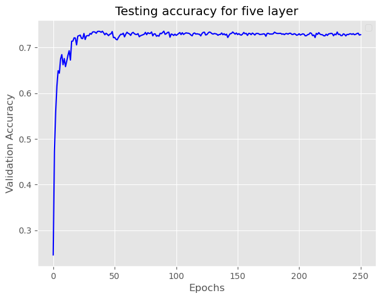

```python
vals_Adam = {'n1_hidden':70, 'n2_hidden':50, 'n3_hidden':30,  'n4_hidden':10, 'beta1':0.999,'beta2':0.9999,
         'C':1e-2, 'epochs':250, 'eta':0.01, 'random_state':3000, 'decrease_iter':20,'eps':1e-7,
         'alpha':0.1, 'decrease_const':0.1, 'minibatches':len(X_train)/256,
         'shuffle':True}

nn_Adam = FiLPAdam(**vals_Adam)
nn_Adam.fit(X_trained, y_trained, print_progress=1, XY_test=(X_tested, y_tested));

print_result(nn_Adam,X_trained, y_trained,X_tested, y_tested,color="blue")
plt.title('Testing accuracy for five layer')
plt.show()
```